# Model Checking

## Fundamental Concepts

### Transition Systems

**Definition 1 (Transition System)** Formaly a transition system $T$ is a tuple $(S, \texttt{Act}, \rightarrow, S_0, \texttt{AP}, L)$ where

- $S$ countable set of **states**
- $\texttt{Act}$ set of **actions**
- $\rightarrow \ \subseteq S \times \texttt{Act}\times S$ a **transition relation**
- $S_0 \subseteq S$ a set of **initial states**
- set of **atomic propositions** $\texttt{AP}$ with
- a **labeling function** $L : S \rightarrow 2^{\texttt{AP}}$ that assigns propositions to each state

**Differences to finite automata**

- Possibly infinity state space.
- No accepting states.
- Multiple initial states.

**Execution Fragment**

An execution fragment of a transition system is an alternating sequence sequence of states and actions:

$$\rho = s_0 \alpha_1 s_1 \alpha_2 \ ... \text{ such that } s_i \xrightarrow{\alpha_{i+1}} s_{i+1}$$

**Maximal**

An execution fragment is maximal iff. it is infinite or it is ending in a terminal state.

**Initial**

An execution fragment is initial iff. it starts in an initial state.

**Execution**

An execution is an initial & maximal execution fragment. (corresponds to run on automata)

**Path**

Let $s_0 \alpha_1 s_1 ...$ be an execution, then $s_0s_1 ...$ is a path. In other words a path is the sequence of states of an execution.

**Reachable fragment**

$Reach(T)$ set of states that appear on some path.

**Trace**

Let $s_0s_1...$ be a path, then $L(s_0)L(s_1)...$ is a trace. In other words a trace is the sequence of atomic propositions that hold along a path.

### Program Graphs

Program graphs are an abstraction of (imperative) programs.

**Definition 2 (Program Graph)** A program graph is a tuple

$$(Loc, \texttt{Act}, Effect, \hookrightarrow, Loc_0, g_0)$$

where

- $Loc$ is a set of **locations** (roughtly corresponds to code lines)
- $\texttt{Act}$ is a set of **actions**
- $Effect: \texttt{Act}\times Eval(Var) \rightarrow Eval(Var)$ models the **effect** of actions
- $\hookrightarrow \subseteq Loc \times Cond(Var) \times \texttt{Act}\times Loc$ is the **edge relation**
- $g_0 \in Cond(Var)$ is the **initial condition**

### Translating Program Graphs to Transition Systems

Let $PG = (Loc, \texttt{Act}, Effect, \hookrightarrow, Loc_0, g_0)$ be a program graph. Then this can be modeled by the transition system $(S, \texttt{Act}, \rightarrow I, \texttt{AP}, L)$ where

- $S = Loc \times Eval(Var)$
- $\rightarrow \subseteq S \times \texttt{Act}\times S$ can be deduced by the following rule

  $$\frac{l \xhookrightarrow{g:\alpha} l' \land \eta \models g} {\langle l, \eta \rangle \xrightarrow{\alpha} \langle l', Effect(\alpha, \eta) \rangle}$$
- $I = \{ \langle l, \eta \rangle | l \in Loc_0, \eta \models g_0 \}$
- $L( \langle l, \eta \rangle) = \{l\} \cup \{g \in Cond(Var) | \eta \models g \}$

### Interleaving

We can model multi-threaded execution **without shared variables** by interleaving the transition systems.

**Definition 3 (Interleaving transition systems)** Let $TS_1, TS_2$ be two transition systems. Then

$$TS_1 \ ||| \ TS_2 := (S_1 \times S_2, \texttt{Act}_1 \uplus \texttt{Act}_2, \rightarrow, I_1 \times I_2, \texttt{AP}_1 \uplus \texttt{AP}_2, L)$$

- $L(\langle s_1, s_2 \rangle) = L_1(s_1) \cup L_2(s_2)$
- And $\rightarrow$ can be deduced by the following rule:
  $$\frac{s_1 \xrightarrow{\alpha} s_1'}
  {\langle s_1, \textcolor{gray}{s_2} \rangle \xrightarrow{\alpha} \langle s_1', \textcolor{gray}{s_2}\rangle}
  \text{ and }
  \frac{s_2 \xrightarrow{\alpha} s_2'}
  {\langle \textcolor{gray}{s_1}, s_2 \rangle \xrightarrow{\alpha} \langle \textcolor{gray}{s_1}, s_2'\rangle}$$

We can model multi-threaded execution **with shared variables** by interleaving the program graphs.

**Definition 4 (Interleaving program graphs)** Let $PG_1, PG_2$ be two program graphs over the **same variables**. Then $PG_1 \ ||| \ PG_2 := (Loc_1 \times Loc_2, \texttt{Act}_1 \uplus \texttt{Act}_2, Effect, \hookrightarrow,$  
$Loc_{0,1} \uplus Loc_{0,2}, g_{0, 1} \land g_{0, 2})$

- $Effect(\alpha, \eta) = Effect_i(\alpha, \eta)$ for $\alpha \in \texttt{Act}_i$.
- And $\hookrightarrow$ can be deduced by the following rule:
  $$\frac{l_1 \xhookrightarrow{g:\alpha} l_1'}
  {\langle l_1, \textcolor{gray}{l_2} \rangle \xhookrightarrow{g:\alpha} \langle l_1', \textcolor{gray}{l_2}\rangle}
  \text{ and }
  \frac{l_2 \xhookrightarrow{g:\alpha} l_2'}
  {\langle \textcolor{gray}{l_1}, l_2 \rangle \xhookrightarrow{g:\alpha} \langle \textcolor{gray}{l_1}, l_2'\rangle}$$

**Important**

In general it **does not hold** that $TS(PG_1) \ ||| \ TS(PG_1) = TS(PG_1 \ ||| \ PG_2)$

**State Explosion Problem**

State space grows **exponentially** with number of **threads** and **variables**.

## Linear Time Properties

**Definition 5 (Linear Time Property)** A **linear-time property** over some atomic propositions $\texttt{AP}$ is a subset of $\left(2^{\texttt{AP}}\right)^\omega$.

A transitionsystem $TS$ satisfies a LT property $P$

$$TS \models P \text{ iff. } Traces(TS) \subseteq P$$

**Invariant**

LT property of the form $A^\omega$ for some $A \subseteq 2^{\texttt{AP}}$ i.e. “some property holds forever”

**Persistance Property**

LT property of the form ${(2^{\texttt{AP}})}^* A^\omega$ i.e. “some property eventually holds forever”

**Closure**

For a LT property $P$ the closure contains all traces $t$ such that for each prefix of $t$ a trace in $P$ has the same prefix.

**Definition 6 (Safety Property)** A LT property $S$ over $\texttt{AP}$ is a **safety property** if for all $\sigma \in (2^{\texttt{AP}})^\omega \setminus S$ we can find a “bad prefix” $\hat{\sigma}$ such that no word in $S$ has prefix $\hat{\sigma}$.

This is equivalent to:

$$cl(S) = S$$

**Definition 7 (Liveness Property)** LT property $L$ over $\texttt{AP}$ is a **liveness property** iff. it “does not exclude a any finite execution”:

$$pref(L) = ({2^{\texttt{AP}}})^*$$

This is equivalent to:

$$cl(L) = 2^{\texttt{AP}}$$

**Theorem 1 (LT-Properties vs Traces)** Let $TS, TS'$ be transition systems without terminal states:

$$\begin{align}
Traces(TS) \quad & \subseteq \quad Traces(TS') \\
& \text{iff.} \\
TS' \models P \quad & \Rightarrow \quad TS \models P
, \text{ for all LT-props } P\\
\end{align}$$

For **safety property** we know that:

$$\begin{align}
Traces_{fin}(TS) \quad & \subseteq \quad Traces_{fin}(TS') \\
& \text{iff.} \\
TS' \models P \quad & \Rightarrow \quad TS \models P
, \text{ for all \textbf{safety} props } P\\
\end{align}$$

**Corollary 1**

$Traces(TS) = Traces(TS')$ iff. $TS$ and $TS'$ satisfy the same LT properties and analogously  
$Traces_{fin}(TS) = Traces_{fin}(TS')$ iff. $TS$ and $TS'$ satisfy the same safety properties.

**Finite Trace Equivalence $\neq$ Trace Equivalence**

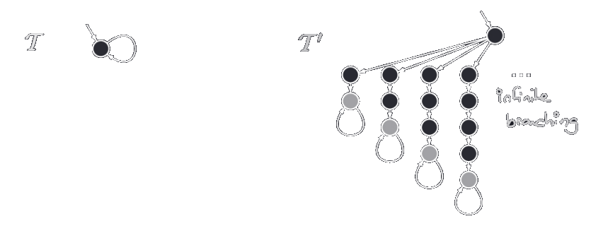

Here $Traces_{fin}(\mathcal{T}) \subseteq Traces_{fin}(\mathcal{T'})$ but $Traces(\mathcal{T}) \not \subseteq Traces(\mathcal{T'})$

**Theorem 2 (Decomposition Theorem)** For every LT-property $P$ we can find a safety-property $E_{save}$ and a liveness-propery $E_{live}$ such that

$$P = E_{save} \cap E_{live}$$

one possible decomposition is given by

$$P = \underbrace{cl(P)}_{E_{safe}} \cap \underbrace{(P \cup ((2^\texttt{AP})^\omega\setminus cl(P))}_{E_{live}}$$

## $\omega$-regular LT-properties

**Definition 8 ($\omega$-regular Expression)** An $\omega$-regular expression has the form:

$$G = E_1.F_1^\omega+ ... + E_n.F_n^\omega$$

where $E_i, F_i$ are regular expressions.

If a LT property can be defined by an $\omega$-regular expression we call it $\omega$-*regular property*

**Definition 9 (Synchronous Product)** Let:

- $TS := (S, \texttt{Act}, \rightharpoonup, I, \texttt{AP}, L)$ without terminal states
- $A := (Q, \Sigma, \rightharpoondown, Q_0, F)$ and NFA
  - $\Sigma = 2^{\texttt{AP}}$ (A has to define traces)
  - $Q_0 \cap F = \emptyset$ (A can’t accept $\varepsilon$ because this safetyproperty would be unsatisfiable)

Then:

$$TS \otimes A := (S', \texttt{Act}, \rightarrow, I', \texttt{AP}', L')$$

- $S' = S \times Q$
- $\texttt{AP}' = Q$
- $L'( \langle s, q \rangle) = \{q\}$
- $\rightarrow$ can be deduced by:

$$\frac{s \xrightharpoonup{\alpha} \textcolor{orange}{t} \land q \xrightharpoondown{L(\textcolor{orange}{t})} p} {\langle {s}, {q} \rangle \xrightarrow{\alpha} \langle {\textcolor{orange}{t}}, {p} \rangle}$$

- $I' = \{ \langle s_0, q \rangle | s_0 \in I \land \exists q_0 \in Q_0 . q_0 \xrightharpoondown{L(s_0)} q \}$

**Theorem 3** Let $TS$ be some transition system. $E_{safe}$ a safety property and $A$ an NFA that recognizes the bad prefixes of $E_{safe}$. Then:

$$TS \models E_{safe} \Leftrightarrow TS \otimes A \text{ has no reachable accepting states}$$

**Definition 10 (Büchi automaton)** A *nondeterministic Büchi automaton* (NBA) is a tuple $(Q, \Sigma, \delta, Q_0, F)$ where:

- $Q$ is a finite set of **states**
- $\Sigma$ is a finite **alphabet**
- $\delta: Q \times \Sigma \rightarrow 2^Q$ a **transition function**
- $Q_0 \subseteq Q$ a set of **initial states**
- $F \subseteq Q$ set of **accepting states**

**Acceptance condition**: There exists a run that **infinitely often** visits an accepting state.

NFA vs. NBA

| Property | NFA | NBA |
| --- | --- | --- |
| Recognizes: | regular languages | $\omega$-regular languages |
| Closure $\cup$ | union operator | union operator |
| Closure $\cap$ | product construction | GNBA product |
| Closure $\neg$ | build DFA and complement F | complex procedure |
| Determinism | NFA = DFA | DBA $\subsetneq$ NBA |

### Verifying $\omega$-regular Safety Properties

**Idea**

Define Büchi automaton $\mathfrak{A}$ for *bad behaviour* $E$. The atomic property $F$ labels all *accepting* states of $\mathfrak{A}$. Check if

$$T \otimes \mathfrak{A} \models \text{ eventually forever } \neg F$$

Here $\otimes$ is defined like in Definition 9.

**Theorem 4 (Persistence Property Check)** Let $P$ be some *persistence property* of the form “$\text{eventually forever } \varphi$”. Then it equivalent:

1. $\Leftrightarrow TS \models P$
2. $\Leftrightarrow \exists s. (s \in \text{Reach}(TS) \land s \not \models \varphi\land s \text{ is on cycle})$
3. $\Leftrightarrow \exists C. (C \text{ is reachable } \land C \text{ is a SCC} \land C \cap \{ s \in S | s \not \models \varphi\} \neq \emptyset)$

**Strongly Connected Component ([SCC](https://en.wikipedia.org/wiki/Strongly_connected_component))**

Set of **states** $C$ such that for all $x, y \in C$: $x$ is *reachable* from $y$.

### SCC Method

- compute all *inclusion maximal* SCCs
- remove unreachable SCCs
- check for a state $s \models \neg \varphi$

**Not practical**

### Cycle Method

**Naïve way:** $\Theta(|V| \cdot |E|)$

- use [DFS](https://en.wikipedia.org/wiki/Depth-first_search) to find states $s \models \neg \varphi$
- use *second* DFS to check wether cycle is reachable from itself (i.e. belongs to cycle)

**Imprövement:** $\Theta(|V| + |E|)$

- use outer DFS to find states $s \models \neg \varphi$
- use inner DFS to check wether cycle is reachable from itself **while avoiding states visited in a previous inner DFS**, i.e. maintain **one** `visited` set across all executions of the inner DFS.

## Linear Temporal Logic (LTL)

**Definition 11** For a set of atomic propositions $\texttt{AP}$ we give the BNF grammar for LTL:

- $\varphi= a \text{ for } a \in \texttt{AP}$
- $\varphi= \texttt{true}| \varphi\lor \varphi| \neg \varphi$
- $\varphi= \bigcirc\varphi$ “next”
- $\varphi= \varphi\textbf{U}\varphi$ “until”

Additionally we will use the following **derived operators**:

- the usual:  
  $\texttt{false}, \lor, \leftarrow, \rightarrow, \leftrightarrow, \otimes$
- modal operators:
  - “eventually” $\diamond\varphi:= \texttt{true}\textbf{U}\varphi$
  - “always” $\square\varphi:= \neg \diamond\neg \varphi$
- temporal operators:
  - “release” $\varphi\textbf{R}\psi := \neg (\neg \varphi\textbf{U}\neg \psi)$
  - “weak until” $\varphi\textbf{W}\psi := (\varphi\textbf{U}\psi) \lor \square\varphi$
  - “strong release” $\varphi\textbf{M}\psi := (\varphi\textbf{R}\psi) \land \diamond\varphi$

### Equivalences

**Dualities**:

- $\neg \square\varphi\equiv \diamond\neg \varphi$
- $\neg \bigcirc\varphi\equiv \bigcirc\neg \varphi$
- $\neg (\varphi\textbf{U}\psi) \equiv \neg \varphi\textbf{R}\neg \psi$
- $\neg (\varphi\textbf{U}\psi) \equiv (\varphi\land \neg \psi) \textbf{R}(\neg \varphi\land \neg \psi)$
- $\neg (\varphi\textbf{W}\psi) \equiv \neg \varphi\textbf{M}\neg \psi$
- $\neg (\varphi\textbf{W}\psi) \equiv (\varphi\land \neg \psi) \textbf{U}(\neg \varphi\land \neg \psi)$

**Absorbtion**:

- $\square\square\varphi\equiv \square\varphi$
- $\diamond\diamond\varphi\equiv \diamond\varphi$
- $\square\diamond\square\varphi\equiv \diamond\square\varphi$
- $\diamond\square\diamond\varphi\equiv \square\diamond\varphi$
- $\varphi\textbf{U}(\varphi\textbf{U}\psi) \equiv \varphi\textbf{U}\psi$
- $(\varphi\textbf{U}\psi) \textbf{U}\psi \equiv \varphi\textbf{U}\psi$

**Distribution**:

- $\bigcirc(\varphi\textbf{U}\psi) \equiv (\bigcirc\varphi\textbf{U}\bigcirc\psi)$
- $\diamond(\varphi\lor \psi) \equiv \diamond\varphi\lor \diamond\psi$
- $\square(\varphi\land \psi) \equiv \square\varphi\land \square\psi$

**Watch out for these false friends**

- $\diamond(\varphi\land \psi) \not \equiv \diamond\varphi\land \diamond\psi$
- $\square(\varphi\lor \psi) \not \equiv \square\varphi\lor \square\psi$

**Expansion**:

- $\diamond\varphi\equiv \varphi\lor \bigcirc\diamond\varphi$
- $\square\varphi\equiv \varphi\land \bigcirc\square\varphi$
- $\varphi\textbf{U}\psi \equiv \psi \lor (\varphi\land \bigcirc(\varphi\textbf{U}\psi))$

### LTL Model Checking

**Definition 12 (Generalized Büchi Automata)** A *Generalized Non-deterministic Büchi Automaton* (GNBA) is a tuple $(Q, \Sigma, \delta, Q_0, \mathfrak{F})$ where

$$\mathfrak{F} = \{ F_1, ..., F_k \} \text{ with } F_i \subseteq Q$$

A run $r_1r_2...$ on this automaton is **accepting** if:

$$\forall F_j. \exists^\infty i. r_i \in F_j$$

**Definition 13 (Closure)**

Let $\varphi$ be an LTL-formula. Then the **closure** of $\varphi$ contains all subformulas of $\varphi$ and their negation[^1]. We denote the closure of $\varphi$ with $cl(\varphi)$.

**Definition 14 (Elementary Sets)** Let $\varphi$ be an LTL-formula. Then a set $B \subseteq cl(\varphi)$ is **elementary** if it is:

1. Maximaly Consistent for $\land, \neg$
   - $\varphi\land \psi \in B \Leftrightarrow \varphi\in B \land \psi \in B$
   - $\varphi\notin B \Leftrightarrow \neg \varphi\in B$
   - $true \in cl(\varphi) \Rightarrow true \in B$
2. Locally Consistent for $\textbf{U}$  
   for every $\varphi\textbf{U}\psi \in cl(\sigma)$:
   - $\psi \in B \Rightarrow \varphi\textbf{U}\psi \in B$
   - $\varphi\textbf{U}\psi \in B \land \psi \notin B \Rightarrow \varphi\in B$

**Definition 15 (LTL to GNBA)** Let $\varphi$ be an LTL-formula over $\texttt{AP}$. We assume that $\varphi$ only contains $\land, \neg, \bigcirc, \textbf{U}$.

- $\Sigma := 2^{\texttt{AP}}$
- $Q :=$ elementary sets of $\varphi$
- $Q_0 :=$ all elementary sets containing $\varphi$
- $B' \in \delta(B, l)$ iff.
  - $l = B \cap \texttt{AP}$ i.e. all outgoing edges are labeled with $B \cap \texttt{AP}$
  - $\bigcirc\varphi\in B \Leftrightarrow \varphi\in B'$
  - $\varphi\textbf{U}\psi \in B \Leftrightarrow (\psi \in B \lor (\varphi\in B \land \varphi\textbf{U}\psi \in B'))$
- $\mathfrak{F} := \{ F_{\varphi_1 \textbf{U}\varphi_2} \ | \ \varphi_1 \textbf{U}\varphi_2 \in cl(\varphi)\}$ where  
  $F_{\varphi_1 \textbf{U}\varphi_2} := \{ B \in Q | \varphi_1 \textbf{U}\varphi_2 \notin B \text{ or } \varphi_2 \in B \}$

**Note**

For NBA $A$ the NBA for $\overline{A}$ has $c^{n^2}$ states in worst case.

Solution: First negate the formula and then construct the NBA. I.E. use $A_{\neg \varphi} \equiv \overline{A}$.

**Size of NBA can be exponential**

The **worst-case** runtime for constructing an NBA that recognizes a formula is **exponential**. This is because the constructed NBA can be exponentially large. For example for $n \in \mathbb{N}$ consider

$$\varphi_n := \bigwedge_{a \in \texttt{AP}} \bigwedge_{0 \leq i < n} (\bigcirc^i a \leftrightarrow \bigcirc^{n+i} a)$$

Intuitively we can see that after reading the first $n$ characters the automaton has to remember for all $0 \leq i < 0$ and every $a \in \texttt{AP}$ if $a$ holds at position $i$.

**Definition 16 (Algorithm for LTL Model Checking)** Given an LTL-formula $\varphi$ and a transition system $TS$.

1. Calculate a GNBA $G_{\neg \varphi}$ that recognizes $\neg \varphi$.
2. Calculate a NBA $A_{\neg \varphi}$ that recognizes the same language as $G_{\neg \varphi}$.
3. Build the synchronous product $TS \otimes A_{\neg \varphi}$
4. Check if $TS \otimes A_{\neg \varphi} \models \diamond\square\neg F$

Time complexity: $O( |TS| \cdot 2^{|\varphi|} )$

## Computation Tree Logic (CTL)

**Definition 17 (CTL)** For a set of atomic propositions $\texttt{AP}$ we give the BNF grammar for **CTL state-formulas**:

- $\Phi = a \text{ for } a \in \texttt{AP}$
- $\Phi = \texttt{true}\mid \Phi \lor \Phi \mid \neg \Phi$
- $\Phi = \exists \varphi\mid \forall \varphi$

And the following grammar for **CTL path-formulas**:

- $\varphi= \bigcirc\Phi$ “next”
- $\varphi= \Phi \textbf{U}\Phi$ “until”

Additionally we will use the same derived operators as with Definition 11:

The model of a CTL formula consists of a transition system and a state.

For a fixed transition system $TS$ with states $S$ we define:

$$Sat(\Phi) = \{ s \in S \mid TS, s \models \Phi \}$$

Let $S_0$ be the set of initial states of $TS$. Then we can lift the *models* relation to transition systems in the following way:

$$TS \models \Phi \quad :\Leftrightarrow \quad S_0 \subseteq Sat(\Phi)$$

### CTL vs LTL

**Theorem 5 (From CTL to LTL)** Let $\Phi$ be a CTL-formula and $\varphi$ the LTL-formula obtained by deleting all quantifiers from $\Phi$. Then:

$$\Phi \equiv \varphi\textbf{ or } \Phi \text{ is not definable in LTL}$$

**From LTL to CTL**

### CTL Model Checking

First bring the formula into existential normal form.

$$\begin{align}
Sat(\texttt{true}) &= S \\
Sat(a) &= \{ s \in S \mid a \in L(s) \} \\
Sat(\neg \Phi) &= S \setminus Sat(\Phi) \\
Sat(\Phi \land \Psi) &= Sat(\Phi) \cap Sat(\Psi) \\
Sat(\exists \bigcirc\Phi) &= \{s \in S \mid Post(s) \cap Sat(\Phi) \neq \emptyset \}\\
Sat(\exists \square\Phi) &= \{s \in S \mid
\exists \Phi \text{-lasso starting in }s\}\\
Sat(\exists (\Phi \textbf{U}\Psi)) &= \{s \in S \mid
\exists \Phi \text{-path from }s
\text{ to a } \Psi \text{-node} \}\\
\end{align}$$

#### How to find nodes with a $\Phi$-lassos *with Fixpoints*

1. Delete all $s$ where $s \not \models \Phi$
2. Delete $s$ if it has no (undeleted) successors.
3. Repeat until no change. (This is the *fixpoint* part of the algo)

#### How to find nodes with a $\Phi$-lassos *with SCCs*

1. Delete all $s$ where $s \not \models \Phi$
2. Find all (non-trivial)[^2] SCCs. These will form the loop part of the lasso.
3. Find all nodes from which an SCC from Step 2 is reachable. This is the rope part of the lasso.

#### How to find nodes with a $\Phi$-path to a $\Psi$-node *with Fixpoints*

1. Mark all $\Psi$-nodes
2. Mark all predecessors of marked nodes
3. Repeat until no change. (This is the *fixpoint* part of the algo)

## Complexity landscape

First we define the considered problems.

**LTL Model Checking Problem (`LTL-QUERY`)**

Given $TS$ and $\varphi$. Does $TS \models \varphi$?

**LTL Satisfiability Problem (`LTL-[UN]SAT`)**

Given $\varphi$. Does a $TS$ exists such that $TS \models \varphi$? [resp. $TS \not \models \varphi$]

**LTL Validity Problem (`LTL-VALID`)**

Given $\varphi$. Does it hold for all $TS$ that $TS \models \varphi$?

This can be extended in the obvious way to `CTL-QUERY`, `CTL-SAT`, `CTL-VALID`. We assume that the reader is familiar with `P`, `NP`, `NP-hard`, `NP-complete`, `co-NP`, …

**`PSPACE`**

TM only needs polynomially large tape.

**`PSPACE-hard`**

All problems $P$ such that **every** problem from `PSPACE` can be reduced to $P$.

**`PSPACE-complete`**

All problems that are in `PSPACE` and `PSPACE-hard`.

**Theorem 7**

The LTL model-checking and sat problem are `co-NP-hard`.

**Reducing `HAM-CYCLE` to `LTL-UNSAT`**

Because `HAM-CYCLE` is in NP we know that `LTL-SAT` is in `co-NP`.

$$\varphi:= \neg \left( \bigwedge_{v \in V} \diamond v \land \square(v \rightarrow \bigcirc\square\neg v) \right)$$

**Theorem 8**

The LTL model-checking problem is `PSPACE-complete`

## Simulation and Bisimulation

**Definition 21 (Bisimulation Relation)** Let $TS, TS'$ be two transition systems. A relation $\mathfrak{R} \subseteq (S \cup S')^2$ is a **bisimulation** for $(TS, TS')$ if:

- $\mathfrak{R}$ is symetric
- $\mathfrak{R}$ is *compatible* with the labeling: $(s, s') \in \mathfrak{R} \Rightarrow L(s) = L'(s')$
- The initial states are similar in the sense that:
  - for all $s \in S_0$ there exists $s' \in S_0'$ such that $(s, s') \in \mathfrak{R}$
  - for all $s' \in S_0'$ there exists $s \in S_0$ such that $(s, s') \in \mathfrak{R}$
- Successor states are similar[^3] in the sense that for all $(s, s') \in \mathfrak{R}$:
  - for all $p \in Post(s)$ there exists $p' \in Post(s')$ such that $(p, p') \in \mathfrak{R}$
  - for all $p' \in Post(s')$ there exists $p \in Post(s')$ such that $(p, p') \in \mathfrak{R}$

**Definition 22 (AP Deterministic)** A transition system $TS$ is **AP-deterministic** if

- $|S_0| \leq 1$
- for all $A \in 2^\texttt{AP}$ we have that $|Post(s) \cap \{ s' \in S | L(s') = A \}| \leq 1$

**Theorem 9 (Bisimilarity vs Trace Equivalence)**

For transition systems $TS_1, TS_2$

$$TS_1 \sim TS_2 \Rightarrow TS_1 \equiv_{trace} TS_2$$

For **AP-deterministic** transition systems $TS_1, TS_2$

$$TS_1 \sim TS_2 \Leftrightarrow TS_1 \equiv_{trace} TS_2$$

**Corollary 2** For transition system TS and states $s, s'$ it is **equivalent**:

- $s \sim s'$
- $s \equiv_{CTL} s'$
- $s \equiv_{CTL*} s'$

## Fairness

Fairness **limits** the set of traces we consider when doing model checking.

We want to remove traces that we consider *unrealistic*.

Which fairness notion?:

- strong fairness good for contentions
- weak fairness good for unfair scheduling

Fairness is concerned with a fair resolution of **non-determinism**.

**Definition 23 (LTL Fairness Constraints)** An LTL fairness constraint is of the form:

$$fair = ufair \land sfair \land wfair$$

where

1. **unconditional** fairness constraint: $ufair = \square\diamond\psi$
2. **strong** fairness constraint: $sfair = \square\diamond\varphi\rightarrow \square\diamond\psi$
3. **weak** fairness constraint: $wfair = \diamond\square\varphi\rightarrow \square\diamond\varphi$

**Corollary 3 (Fairness Suffix Property)** For any fair path $\pi$ it holds

1. all suffixes of $\pi$ are fair
2. for any finite path fragment $\sigma$ the extension $\sigma.\pi$ is fair

**Definition 24 (Realisable Fairness)** A fairness assumption $fair$ is **realisable** for $TS$ iff. for all reachable states $s$:

$$FairPaths_{fair}(s) = \{\pi \in Paths(s) \mid \pi \models fair \} \neq \emptyset$$

this is equivalent to

Every initial finite path fragment can be completed to a fair run.

**Corollary 4 (Safety Properties are preserved under realisable fairness)**

$$TS \models E_{safe} \text{ iff. } TS \models_{fair} E_{safe}$$

### LTL Fairness Model Checking

- transition system $TS$
- LTL formula $\varphi$
- an LTL fairness assumption $fair$

Question: does $TS \models_{fair} \varphi$

Can be reduced to normal model checking by considering $(fair \rightarrow \varphi)$

### CTL Fairness Model Checking

- transition system $TS$
- CTL formula $\varphi$
- an CTL fairness assumption $fair$

Question: does $TS \models_{fair} \varphi$

include fairness checking by **limiting** $\forall, \exists$ quantifiers to **fair paths**.

How to change algo

- add fresh atomic propositions for fairness conditions
- when considering quantifiers check if the final path fragment is fair

## Bisimulation Quotient

**Definition 25** For $TS = (S, \texttt{Act}, \rightarrow, I, \texttt{AP}, L)$ and its coarsest bisimulation $\sim_{TS} \subseteq S \times S$. We define the *quotient transition system*

$$TS / \sim_{TS} = (S / \sim_{TS}, \{\tau\}, \rightarrow', I', \texttt{AP}, L')$$

where

- $S / \sim_{TS} = \{ [s]_\sim | s \in S \}$
- $I' = \{ [s]_\sim | s \in I \}$
- $L'([s]_\sim) = L(s)$
- $s \rightarrow' s' \Leftrightarrow [s]_\sim \rightarrow [s']_\sim$

**Theorem 10**

Every transition system is bisimilar to its **bisimulation quotient**.

How to find a quotient.

**block**

pars of partition

**super-block**

nonempty union of blocks

a partition $P$ is *finer* than another partition $P'$ iff every every block of $P$ is a super-block in $P'$

```
P := {(s, t) | L(s) = L(t)} // group states
                            // with equal
                            // atomic propositions
while (P != Refine(P))      // fixpoint iteration
  { P := Refine(P) }
```

We can refine the partition with a super-block $C$:

[output not shown]

Strategies to choose $C$:

1. **Simple** (Kanalakis&Smoka): try **all** blocks $O(\# \text{states} \cdot \# \text{transitions})$
2. **Advanced** (Page&Tarjan):
   - step $n$: we split $B \in P$ into $B_1, B_2$ such that $|B_1| < |B_2|$,
   - step $n+1$: we can calc `Refine(Refine(P, B_1), B_2)` by subroutine:

[output not shown]

## Simulation Preorder

**Definition 26 (Abstraction Function)**

$f : S \rightarrow \hat{S}$ is an abstraction function if $f(s) = f(s') \Rightarrow L(s) = L(s')$

**Definition 27 (Abstraction Transition System)** For $TS = (S, \textcolor{gray}{\texttt{Act}}, \rightarrow, I, \textcolor{gray}{\texttt{AP}}, L)$ and abstraction function $f : S \rightarrow \hat{S}$ we define the **abstraction** of $TS$:

$$TS_f = (\hat{S}, \textcolor{gray}{\texttt{Act}}, \rightarrow_f, I_f, \textcolor{gray}{AP}, L)$$

- $f(s) \rightarrow_f f(s') \Leftrightarrow s \rightarrow s'$
- $I_f = f(I)$
- $L_f(f(s)) = L(s)$ (well defined because $f$ is an abstraction)

**Lemma 2**

The relation $\mathfrak{R} = \{ (s, f(s)) | s \in S \}$ is a **simulation** for $(TS, TS_f)$.

**Definition 28 (Simulation Equivalence)**

$$TS_1 \approxeq TS_2 \quad \text{ iff. } \quad TS_1 \leq TS_2 \text{ and } TS_2 \leq TS_1$$

**Definition 29 (Universal fragment of $CTL^*$)** State formulas:

$$\Phi ::= \texttt{true}| \texttt{false}| a | \neg a | \Phi \land \Phi | \Phi \lor \Phi | \forall \varphi$$

Path formulas:

$$\varphi::= \Phi | \bigcirc\varphi| \varphi\land \varphi| \varphi\lor \varphi| \varphi\textbf{U}\varphi| \varphi\textbf{R}\varphi$$

**Lemma 3**

For every LTL formula there exists an equivalent $\forall CTL^*$ formula

**Theorem 11 (Simulation equivalence and $CTL$)** Let $TS$ be a *finitely branching* and $s, s'$ states in $TS$. Then it is equivalent:

- $\Leftrightarrow$ $s \leq s'$
- $\Leftrightarrow$ for any $\Phi \in \forall CTL^*$: $(s \models \Phi) \Leftarrow (s' \models \Phi)$
- $\Leftrightarrow$ for any $\Phi \in \forall CTL$: $(s \models \Phi) \Leftarrow (s' \models \Phi)$
- $\Leftrightarrow$ for any $\Phi \in \forall CTL_{\setminus \textbf{U}, \textbf{R}}$: $(s \models \Phi) \Leftarrow (s' \models \Phi)$

## Stuttering

**Definition 30 (Stutter step)**

A transition $s \rightarrow s'$ is a **stutter step** if $L(s) = L(s')$

**Definition 31 (Stutter Path Equivalence)**

Paths $\pi_1$ and $\pi_2$ are **stutter equivalent** if $trace(\pi_1)$ and $trace(\pi_2)$ are both of the form $A_0^+A_1^+A_2^+...$

**Definition 32 (Stutter Trace Equivalence)** Transitionsystems $TS_1, TS_2$ are **stutter trace equivalent** if

$$Traces(TS_1) /_{\equiv_\text{sttrace}} \ = \ Traces(TS_2) /_{\equiv_\text{sttrace}}$$

**Definition 33 (Stutter Bisimilarity)**

**Stutter Path**

Trace that only stutters. We say it **diverges**.

**Divergent state**

A state from which there exists a stutter path.

**Stutter Bisimilarity vs Stutter Trace Equivalence**

*Stutter bisimilarity* **DOES NOT** imply *stutter trace equivalence*. This is because stutter bisimilarity does not impose constraints on stutter paths.

**Definition 34 (Divergent-Sensitive Stutter Bisimilarity)**

Bisimilarity where divergent states are only paired with divergent states.

### Divergent-Sensitive Stutter Bisimilarity vs Stutter Trace Equivalence

Divergent-sensitive stutter trace bisimilarity *implies* stutter trace equivalence.

**Theorem 12 (Divergent-Sensitive Stutter Bisimilarity vs CTL)** For a **finitely branching** $TS$ and states $s, s'$ it is equivalent:

- $\Leftrightarrow$ $s \approx^{div}_{TS} s'$
- $\Leftrightarrow$ $s \equiv_{CTL_{\setminus \bigcirc}} s'$
- $\Leftrightarrow$ $s \equiv_{CTL_{\setminus \bigcirc}^*} s'$

### Refinement Algorithm

**$Pre_\Pi^*(B, C)$**

All stutter-step predecessors of $C$ that are in $B$

**Splitters**

A superblock $C$ is a splitter for a pars $B$ if $B \neq C$, $B \cap Pre(C) \neq \emptyset$ and $B \setminus Pre_\Pi^*(B, C) \neq \emptyset$

```
Refine(B, C) = {B ∩ Pre*(B, C), B \ Pre*(B, C)} \ ø
```

**Stutter Cycle**

Cycle that only consists of stutter steps. All states on a stutter cycle are *divergent-sensitive stutter bisimilar*

#### Performance Improvements

- Find SCCs that only contain stutter steps
- Collapse every Stutter SCC into a single state

**Exit/Bottom state**

state in a block whose successors are all outside the block.

No stutter cycles => each block has an exit state

For finite TS without stutter cycles:

$$B \setminus Pre_\Pi^*(B, C) \neq \emptyset \Leftrightarrow Bottom(B) \setminus Pre(C) \neq \emptyset$$

Time Complexity: $O(\# \text{states} \cdot \# \text{transitions})$

- **Definition 35 (Divergence Expansion)**
- Add new state $s_{div}$ with $L(s_{div}) = div$
- Add selfloop $s_{div} \rightarrow^\tau s_{div}$
- Add edge from every divergent state on a stutter cycle to $s_{div}$

On this expanded TS divergent-sensitive stutter bisimilarity and normal stutter bisimilarity coincide.

Destillation: * replace $s \rightarrow s_{div}$ with $[s] \rightarrow [s]$ * delete $s_{div}$

## Partial Order Reduction

**Idea**

Sometimes the order of actions is not important. We can reduce the statespace by choosing one “representative” permutation of independent actions.

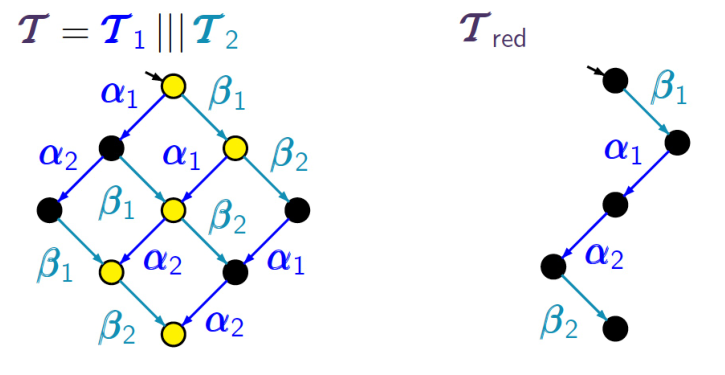

Diamond

**Definition 36 (Action Deterministic)** $TS$ is **action deterministic** iff for all states $s$:

$$s \xrightarrow{\alpha} u \land s \xrightarrow{\alpha} v \Rightarrow u=v$$

**How to make a TS action deterministic**

If for some state $s$ there exists two outgoing edges with the same action $\alpha$ we introduce a new action $\alpha'$ and label one of the edges with it.

**Definition 37 (Action Independence)** Let $TS$ be an *action-deterministic* transition system. Then $\alpha, \beta \in \texttt{Act}$ are called **independent** if for all states with $\alpha, \beta \in \texttt{Act}(s)$:

$$\beta \in \texttt{Act}(\alpha(s)) \land \alpha \in \texttt{Act}(\beta(s)) \land \beta(\alpha(s)) = \alpha(\beta(s))$$

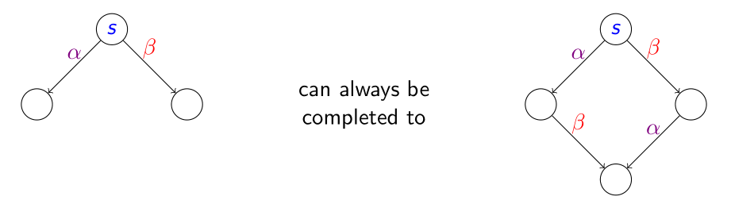

Action Independence Diamond

We say $\alpha$ is independent of $B \subseteq \texttt{Act}\setminus \{\alpha\}$ iff alpha is independent of every action in $B$.

**Stutter Action**

An action where each transition is a **stutter step**.

**Definition 38 (Ample Sets)** For each state $s$ we select a subset of outgoing edges $ample(s) \subseteq \texttt{Act}(s)$ that satisfies the following conditions:

1. **Non-emptiness condition** Select at least one action in every state. $\forall s. ample(s) \neq \emptyset$
2. **Dependency condition** in the original TS: an action depending on $ample(s)$ can only occur **after** some action in $ample(s)$ has occurred.
3. **Stutter condition** If an enabled action is not selected, then all selected actions are stutter actions. $\forall s. (ample(s) \neq Act(s) \rightarrow ample(s) \subseteq Act_{stutter})$
4. **Cycle condition** Any action in $\texttt{Act}(s_i)$ (in TS) with $s_i$ on a cycle in $TS_{red}$ must be selected in some $s_i$ on that cycle.

**Definition 39 (Ample Set Reduction)** For $TS$ and ample sets $ample: S \rightarrow 2^\texttt{Act}$ we define the **reduced** transition system

$$TS_{red} := (S', \texttt{Act}, \Rightarrow, I, \texttt{AP}, L_{|S'})$$

where:

- $s \Rightarrow^\alpha s'$ iff. $s \rightarrow^\alpha s' \land \alpha \in ample(s)$
- $S'$ are all states that are reachable via $\Rightarrow$
- $L_{|S'} : S \rightarrow \mathfrak{P}(\texttt{AP}), s \mapsto L(s)$ is the reduction of $L$ to $S'$.

## Symbolic Model Checking

**Evaluation**

Function that assigns a value to every variable $\nu : Var \rightarrow \{0, 1\}$

**Switching Function**

A function that assigns a boolean value to an *evaluation* $f : 2^{Var} \rightarrow \{0, 1\}$. Can be used to encode sets

### Representing Switching Functions

**Binary Decision Tree (BDT)**

Full binary tree of depth $\#\text{variables}$ The path to a leaf encodes an evaluation.

**Ordered Binary Decision Diagram (OBDD)**

Acyclic Graph. Isomorphic subgraphs are collapsed into one node.

$f_v = \underbrace{(z \land (f_{succ_1(v)})) \lor (\neg z \land (f_{succ_0(v)}))}_\text{Shannon expansion}$

**Definition 40 (Consistent Cofactor)** Let $v_1 <_\rho ... <_\rho v_n$ be some variabel order and $f$ a switching function on $Var = \{v_1,...,v_n\}$. Then $g$ is a **consistent cofactor** iff

$$\exists i.\exists c_1,...,c_i. (g = f|_{[v_1=c_1,...,v_i = c_i]})$$

In other words

$$g : 2^{n-i} \rightarrow \{0, 1\} \ , \ (x_{i+1}, ... x_{n}) \mapsto f(\textcolor{gray}{c_1,...,c_i},x_{i+1}, ..., x_n)$$

**Reduced OBDD**

OBDD without isomorphic subtrees.

**Theorem 13 (Universality and Canonicity)** For finite $Var$, fixed ordering and switching function.

1. There exists a ROBDD
2. Each pair of switching functions is isomorphic

**Essential Variable**

A variable $x$ is essential iff $f|_{[x=1]} \neq f|_{[x=0]}$.

**Symmtric function**

Generalisation of kommutativity to functions with $\geq 2$ arguments. Means that function result is independent of permutation of inputs. $f(x) = f(\sigma(x))$ for every permutation $\sigma$.

**Lemma 4 (Size of ROBDD for Symmetric Functions)**

Let $f$ be a symmetric function with $m$ essential variables. Then for each variable ordering the ROBDD has size $O(m^2)$

Finding best permutation of variables is very hard.

**Variable Sifting**

Choose some x_i. For all j try order: $x_1,...x_{j-1}, x_i, x_{j},...,x_n$

**Interleaved Variable Order**

Encode binary relation $(x, y)$ with n bits as $x_1,y_1,x_2,y_2,...x_n, y_n$. In practice good to encode transition relations.

**Shared OBDD**

ROBDD with multiple root nodes. Can be used to encode *multiple* switching functions.

Implementation of SOBDDs

1. **unique** table
- entries: $\langle var(v), succ_1(v), succ_0(v) \rangle$
- main operation: `find_or_add(z, v1, v2)`
- keeps track of already created nodes
- implemented using hash-tables

**Definition 41 (ITE normal form)** We introduce the **if-then-else** operator $ITE(g, f_1, f_2) := (g \land f_1) \lor (\neg g \land f_0)$

We can “push” substitutions inside:

$$(ITE(g, f_1, f_2)) |_{[v := b]} = ITE(g|_{[v := b]}, f_1|_{[v := b]}, f_2|_{[v := b]})$$

**Convert ITE to SOBDD**:

$$\frac{f := ITE (g, f_1, f_2)}{ ITE (v^\bot, f|_{[v^\bot := 1]}, f|_{[v^\bot := 0]}) }$$

where $v^\bot$ is the least variabel according to our variable ordering.

## SAT-based Bounded Model Checking

Checks for bugs of bounded length.

Only used for LTL because CTL-counterexamples are harder to reason about.

**Idea**

For a given $k$: unroll the TS to paths of length $k$ and check for property. Unroll formulas as well.

**Definition 42** An infinite path $\rho$ is a $(k, l)$-lasso iff:

$$\forall i \geq 0. \quad \rho(l+i) = \rho(k+1 + i)$$

i.e. the path is of the form

$$\underbrace{s_0 s_1 s_2 ... s_{l-1}}_\text{stem} \underbrace{(s_l ... s_k)^\omega}_\text{loop}$$

## Footnotes

[^1]: where $\psi$ and $\neg \neg \psi$ are identified
[^2]: >0 transition
[^3]: in MaLo this property is called “Hin&Her Eigenschaft”